# lab4a_1.2

## Diabetes Data

```
## Rows: 442
## Columns: 11
## $ age <int> 59, 48, 72, 24, 50, 23, 36, 66, 60, 29, 22, 56, 53, 50, 61, 34, 4…
## $ sex <int> 2, 1, 2, 1, 1, 1, 2, 2, 2, 1, 1, 2, 1, 2, 1, 2, 1, 2, 1, 1, 1, 2,…
## $ bmi <dbl> 32.1, 21.6, 30.5, 25.3, 23.0, 22.6, 22.0, 26.2, 32.1, 30.0, 18.6,…
## $ map <dbl> 101.00, 87.00, 93.00, 84.00, 101.00, 89.00, 90.00, 114.00, 83.00,…
## $ tc  <int> 157, 183, 156, 198, 192, 139, 160, 255, 179, 180, 114, 184, 186, …
## $ ldl <dbl> 93.2, 103.2, 93.6, 131.4, 125.4, 64.8, 99.6, 185.0, 119.4, 93.4, …
## $ hdl <dbl> 38, 70, 41, 40, 52, 61, 50, 56, 42, 43, 46, 32, 62, 49, 72, 39, 7…
## $ tch <dbl> 4.00, 3.00, 4.00, 5.00, 4.00, 2.00, 3.00, 4.55, 4.00, 4.00, 2.00,…
## $ ltg <dbl> 4.8598, 3.8918, 4.6728, 4.8903, 4.2905, 4.1897, 3.9512, 4.2485, 4…
## $ glu <int> 87, 69, 85, 89, 80, 68, 82, 92, 94, 88, 83, 77, 81, 88, 73, 81, 9…
## $ y   <int> 151, 75, 141, 206, 135, 97, 138, 63, 110, 310, 101, 69, 179, 185,…
```

## Question 1.

**Try doing backward selection using AIC first.**

```
##
## Call:
## lm(formula = y ~ sex + bmi + map + tc + ldl + ltg, data = diabetes)
##
## Residuals:
##      Min       1Q   Median       3Q      Max
## -158.275  -39.476   -2.065   37.219  148.690
##
## Coefficients:
##              Estimate Std. Error t value Pr(>|t|)
## (Intercept) -313.7666    25.3848 -12.360  < 2e-16 ***
## sex          -21.5910     5.7056  -3.784 0.000176 ***
## bmi            5.7111     0.7073   8.075 6.69e-15 ***
## map            1.1266     0.2158   5.219 2.79e-07 ***
## tc            -1.0429     0.2208  -4.724 3.12e-06 ***
## ldl            0.8433     0.2298   3.670 0.000272 ***
## ltg           73.3065     7.3083  10.031  < 2e-16 ***
## ---
## Signif. codes:  0 '***' 0.001 '**' 0.01 '*' 0.05 '.' 0.1 ' ' 1
##
## Residual standard error: 54.06 on 435 degrees of freedom
## Multiple R-squared:  0.5149, Adjusted R-squared:  0.5082
## F-statistic: 76.95 on 6 and 435 DF,  p-value: < 2.2e-16
```

## Question 2.

**Explore the forwards selection technique, which works very similarly to backwards selection, just set direction = “forward” in the step() function. When using direction = “forward” you need to specify a scope parameter: scope = list(lower = M0, upper = M1).**

```
##
## Call:
## lm(formula = y ~ bmi + ltg + map + tc + sex + ldl, data = diabetes)
##
## Residuals:
##      Min       1Q   Median       3Q      Max
## -158.275  -39.476   -2.065   37.219  148.690
##
## Coefficients:
##              Estimate Std. Error t value Pr(>|t|)
## (Intercept) -313.7666    25.3848 -12.360  < 2e-16 ***
## bmi            5.7111     0.7073   8.075 6.69e-15 ***
## ltg           73.3065     7.3083  10.031  < 2e-16 ***
## map            1.1266     0.2158   5.219 2.79e-07 ***
## tc            -1.0429     0.2208  -4.724 3.12e-06 ***
## sex          -21.5910     5.7056  -3.784 0.000176 ***
## ldl            0.8433     0.2298   3.670 0.000272 ***
## ---
## Signif. codes:  0 '***' 0.001 '**' 0.01 '*' 0.05 '.' 0.1 ' ' 1
##
## Residual standard error: 54.06 on 435 degrees of freedom
## Multiple R-squared:  0.5149, Adjusted R-squared:  0.5082
## F-statistic: 76.95 on 6 and 435 DF,  p-value: < 2.2e-16
```

## Question 3.

**Try using the add1() and drop1() functions. The general form is add1(fitted.model, test = “F”, scope = M1) or drop1(fitted.model, test = “F”)**

```r
add1(step_forward_aic, test = "F", scope = M1) # add shows the possible varibles that can be added to the model
```

```
## Single term additions
##
## Model:
## y ~ bmi + ltg + map + tc + sex + ldl
##        Df Sum of Sq     RSS    AIC F value Pr(>F)
## <none>              1271494 3534.3
## age     1      10.9 1271483 3536.3  0.0037 0.9515
## hdl     1     394.8 1271099 3536.1  0.1348 0.7137
## tch     1    3686.2 1267808 3535.0  1.2619 0.2619
## glu     1    3532.6 1267961 3535.0  1.2091 0.2721
```

```r
drop1(step_forward_aic, test = "F") # drop shows the possible variables that can be omitted from the model
```

```
## Single term deletions
##
## Model:
## y ~ bmi + ltg + map + tc + sex + ldl
##        Df Sum of Sq     RSS    AIC F value    Pr(>F)
## <none>              1271494 3534.3
## bmi     1    190592 1462086 3594.0  65.205 6.687e-15 ***
## ltg     1    294092 1565586 3624.2 100.614 < 2.2e-16 ***
## map     1     79625 1351119 3559.1  27.241 2.787e-07 ***
## tc      1     65236 1336730 3554.4  22.318 3.123e-06 ***
## sex     1     41856 1313350 3546.6  14.320 0.0001758 ***
## ldl     1     39377 1310871 3545.7  13.472 0.0002723 ***
## ---
## Signif. codes:  0 '***' 0.001 '**' 0.01 '*' 0.05 '.' 0.1 ' ' 1
```

## Question 4.

**What if you try backwards selection using an individual p-value approach, i.e. using drop1() from the full model.**

```r
drop1(M1, test = "F")
```

```
## Single term deletions
##
## Model:
## y ~ age + sex + bmi + map + tc + ldl + hdl + tch + ltg + glu
##        Df Sum of Sq     RSS    AIC F value    Pr(>F)
## <none>              1263986 3539.6
## age     1        82 1264068 3537.7  0.0281 0.8670306
## sex     1     44999 1308984 3553.1 15.3439 0.0001042 ***
## bmi     1    179033 1443019 3596.2 61.0477 4.296e-14 ***
## map     1     72100 1336086 3562.2 24.5852 1.024e-06 ***
## tc      1     10600 1274586 3541.3  3.6144 0.0579476 .
## ldl     1      5799 1269785 3539.7  1.9774 0.1603902
## hdl     1       663 1264649 3537.9  0.2260 0.6347233
## tch     1      3526 1267512 3538.9  1.2024 0.2734587
## ltg     1     56016 1320001 3556.8 19.1005 1.556e-05 ***
## glu     1      3080 1267066 3538.7  1.0504 0.3059895
## ---
## Signif. codes:  0 '***' 0.001 '**' 0.01 '*' 0.05 '.' 0.1 ' ' 1
```

```r
M2 = update(M1, . ~ . - age) # age has the highest p-value
drop1(M2, test = "F")
```

```
## Single term deletions
##
## Model:
## y ~ sex + bmi + map + tc + ldl + hdl + tch + ltg + glu
##        Df Sum of Sq     RSS    AIC F value    Pr(>F)
## <none>              1264068 3537.7
## sex     1     45830 1309898 3551.4 15.6624 8.850e-05 ***
## bmi     1    179084 1443152 3594.2 61.2027 3.993e-14 ***
## map     1     73847 1337915 3560.8 25.2376 7.432e-07 ***
## tc      1     10569 1274637 3539.4  3.6120   0.05803 .
## ldl     1      5751 1269820 3537.7  1.9656   0.16163
## hdl     1       646 1264715 3535.9  0.2209   0.63856
## tch     1      3543 1267611 3536.9  1.2107   0.27180
## ltg     1     55964 1320032 3554.8 19.1258 1.535e-05 ***
## glu     1      3001 1267069 3536.7  1.0257   0.31173
## ---
## Signif. codes:  0 '***' 0.001 '**' 0.01 '*' 0.05 '.' 0.1 ' ' 1
```

```r
M3 = update(M2, . ~ . - hdl) # hdl has the highest p-value
drop1(M3, test = "F")
```

```
## Single term deletions
##
## Model:
## y ~ sex + bmi + map + tc + ldl + tch + ltg + glu
##        Df Sum of Sq     RSS    AIC F value    Pr(>F)
## <none>              1264715 3535.9
## sex     1     46381 1311096 3549.8 15.8794 7.920e-05 ***
## bmi     1    178542 1443256 3592.3 61.1273 4.111e-14 ***
## map     1     73533 1338248 3558.9 25.1756 7.655e-07 ***
## tc      1     26839 1291554 3543.2  9.1890  0.002581 **
## ldl     1      7505 1272219 3536.5  2.5694  0.109677
## tch     1      3247 1267961 3535.0  1.1116  0.292320
## ltg     1     97508 1362223 3566.7 33.3840 1.447e-08 ***
## glu     1      3093 1267808 3535.0  1.0590  0.304011
## ---
## Signif. codes:  0 '***' 0.001 '**' 0.01 '*' 0.05 '.' 0.1 ' ' 1
```

```r
M4 = update(M3, . ~ . - glu) # (same)
drop1(M4, test = "F")
```

```
## Single term deletions
##
## Model:
## y ~ sex + bmi + map + tc + ldl + tch + ltg
##        Df Sum of Sq     RSS    AIC F value    Pr(>F)
## <none>              1267808 3535.0
## sex     1     44684 1312492 3548.3 15.2965 0.0001066 ***
## bmi     1    189976 1457784 3594.7 65.0331 7.248e-15 ***
## map     1     82152 1349960 3560.7 28.1225 1.818e-07 ***
## tc      1     26378 1294186 3542.1  9.0298 0.0028101 **
## ldl     1      7472 1275280 3535.6  2.5577 0.1104828
## tch     1      3686 1271494 3534.3  1.2619 0.2619190
## ltg     1    102520 1370328 3567.3 35.0950 6.399e-09 ***
## ---
## Signif. codes:  0 '***' 0.001 '**' 0.01 '*' 0.05 '.' 0.1 ' ' 1
```

```r
M5 = update(M4, . ~ . - tch) # (same)
drop1(M5, test = "F") # all have less than a 5% level of significance (i.e. change)
```

```
## Single term deletions
##
## Model:
## y ~ sex + bmi + map + tc + ldl + ltg
##        Df Sum of Sq     RSS    AIC F value    Pr(>F)
## <none>              1271494 3534.3
## sex     1     41856 1313350 3546.6  14.320 0.0001758 ***
## bmi     1    190592 1462086 3594.0  65.205 6.687e-15 ***
## map     1     79625 1351119 3559.1  27.241 2.787e-07 ***
## tc      1     65236 1336730 3554.4  22.318 3.123e-06 ***
## ldl     1     39377 1310871 3545.7  13.472 0.0002723 ***
## ltg     1    294092 1565586 3624.2 100.614 < 2.2e-16 ***
## ---
## Signif. codes:  0 '***' 0.001 '**' 0.01 '*' 0.05 '.' 0.1 ' ' 1
```

## Question 5.

**Are you satisfied with the model you have arrived at? Check the assumptions.**

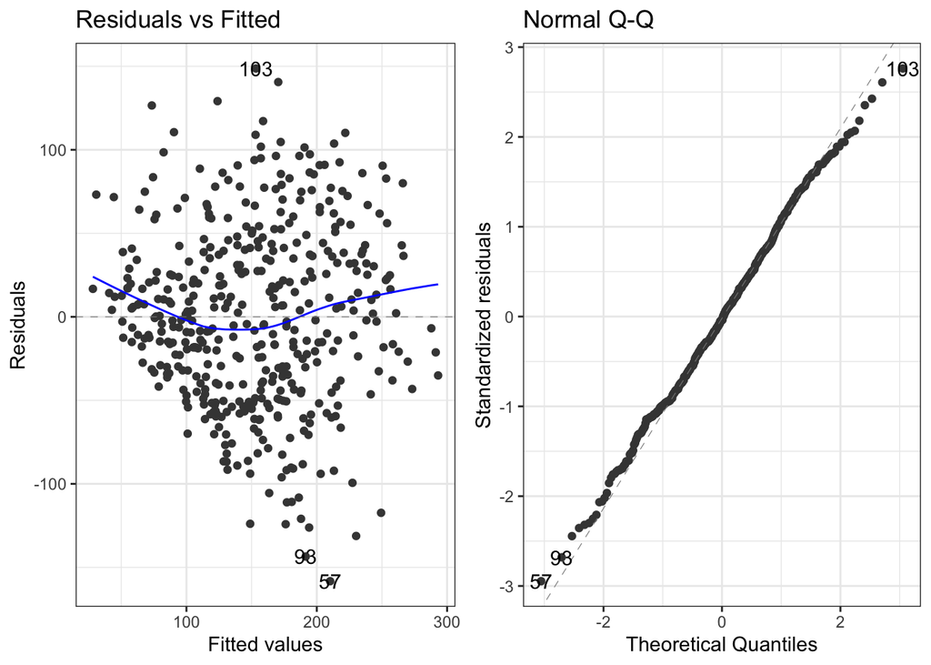

There is a fanning shape in the residuals (close spread for small fitted values and spread out for large fitted values) therefore, the there is no strong evidence for the homoscedasticity assumption. However, there is strong evidence for the normality assumption.

## Question 6

**Write down your final fitted model and interpret the estimated coefficients.**

```
##
## Call:
## lm(formula = y ~ sex + bmi + map + tc + ldl + ltg, data = diabetes)
##
## Coefficients:
## (Intercept)          sex          bmi          map           tc          ldl
##   -313.7666     -21.5910       5.7111       1.1266      -1.0429       0.8433
##         ltg
##     73.3065
```

$\hat{y}=-313.77 - 21.59\times\mbox{sex} + 5.71\times\mbox{bmi} + 1.13\times\mbox{map} - 1.04\times\mbox{tc} + 0.84\times\mbox{ldl} + 73.31\times\mbox{ltg}$

- On average, 1 increase of sex, bmi, map, tc, ldl, ltg results in a $\beta_i$ increase of $y$ (which is the diabetes disease progression)